# Complete forecasts (predictions) demonstrated using CRPS-Net

[figure not shown]

## Why bother with estimating prediction uncertainty?

Properly accounting for uncertainty can lead to better decision making. For example, imagine you are a grower and you know that you have a hard time working in your field due to mud if it rains more than 2 inches in 24 hours. If you were to use a deterministic forecast (single predicted value, like what you probably see on your phone's default weather app) to figure out if you will be able to work in your fields tomorrow and the forecast is calling for 1.4 inches of rain you might think you were good to go. However, in the back of your head you know that weather forecasts can be wrong (as an atmospheric scientist I am sorry about this, there are lots of reasons for this that I do not have time to get into right now. If you are curious, [here](https://www.ecmwf.int/en/research/modelling-and-prediction/quantifying-forecast-uncertainty) is a good resource to learn more about this). Often times people do some kind of three dimensional chess in their heads and think things like, "O.K. the weather app says it is going to rain 1.4 inches, historically I know that could mean anywhere between 0.1 and 3 inches of rain might fall." Wouldn't it be handy if the forecasting system was transparent about how confident it was in its own prediction and did this for you? What if instead of a forecast for 1.4 inches of rainfall, the forecasting system was able to tell you 1.4 inches with a 60% chance of exceeding 2 inches. With this forecast, making plans to work in the field tomorrow suddenly seems less full proof, *i.e.* the decision is not so cut and dry (bazinga). Now imagine that the forecast two days from now gave only a 5% chance of more than two inches of rain. If you had confidence in the forecasting system you would probably decide to work in the field the day the chance of mud was lower. If you were to play out this scenario hundreds of times and the forecast probabilities were reliable (*see note on reliability below) (meaning events that were given some X% chance to occur actually occurred X% of those times, for all percentages), the grower that made decisions using this system would save lots of time.

[figure not shown]

**Muddy fields can be extremely challenging for growers to work in.**

The value of these kinds of predictions has long been established in the field of [Numerical Weather Prediction (NWP)](https://www.ncdc.noaa.gov/data-access/model-data/model-datasets/numerical-weather-prediction) (e.g. [1](https://www.ecmwf.int/sites/default/files/elibrary/2012/14557-ecmwf-ensemble-prediction-system.pdf), [2](https://journals.ametsoc.org/view/journals/mwre/146/5/mwr-d-17-0250.1.xml), [3](https://towardsdatascience.com/probabilistic-predictions-fe04214bde48)). The same principals that make them useful in the weather prediction domain ($i.e.$ weather forecasting) apply to predictions made using Machine Learning (hereafter ML) models. [Buizza 2008](https://rmets.onlinelibrary.wiley.com/doi/10.1002/asl.170) states some of these benefits with great brevity and clarity (simply interchange ML-based predictions for weather forecasts to see the broader benefit). They state, "Probabilistic forecasts (predictions) designed to estimate the probability density function of forecast (prediction) states are potentially more valuable than single forecasts (predictions) because (1) they can predict not only the most likely outcome but also the probability of occurrence of extreme and rare events". In other words, a (good) probabilistic prediction reliably represents the true uncertainty of a given forecasting system, and transparently conveys the whole range of possible outcomes (I like to also call this a *complete forecast*). In the weather forecasting domain, sources of uncertainty include not knowing the true state of the atmosphere before integrating (forward in time) the so-called [physical equations](https://en.wikipedia.org/wiki/Primitive_equations) of the atmosphere (also imperfect) to make future predictions ([many more details here](https://www.ecmwf.int/sites/default/files/elibrary/2012/14557-ecmwf-ensemble-prediction-system.pdf)). In Machine learning, sources of uncertainty may include flawed or incomplete features to properly map the feature space to the target variable, numerical roundoff, bias-variance tradeoffs, not enough data, not converging on the optimal loss function minima while training, $etc$...

Luckily CRPS-Net can help! CRPS-Net makes it easy to make predictions that reliably portray the $range$ of possible outcomes ($y_{pred}$ as a probability density function) rather than a single point estimate. What are the downsides? None! Well, close anyways. The most common opposition to probabilistic predictions are that they are 1) Hard to interpret and 2) computationally expensive. CRPS-Net and Ensemble, both of which will be demonstrated by this notebook, help to overcome these barriers.

*Quick Note on reliability: Probability forecasts are considered reliable when, evaluated over many cases, forecast probability (p) matches the observed relative frequency. What? This means a forecasting system is reliable if it rains 10% of the time a forecasting system calls for a 10% chance of rain. Somewhat annoyingly this means you need to wait around a while before saying, "the forecast was wrong!". Also somewhat annoyingly, this means you do not get to say, "the forecast was wrong" if a 51% chance of rain was predicted and no rain occurred. Probabilities are not winner takes all elections. If it rained 51/100 times a 51% chance of rain was given, the forecast was perfect! This is often measured using a [verification rank histogram](https://journals.ametsoc.org/view/journals/mwre/129/3/1520-0493_2001_129_0550_iorhfv_2.0.co_2.xml).

**Fun aside:** Usually when you see "% chance of rain" from some forecasting system it is referring to 0.01 inches of rain occurring in some time period. It has nothing to do with precipitation quantity. A 90% chance of rain does not mean more rain than 50%, just a higher chance of 0.01 inches.

## Getting started with CRPS-net

The rest of this notebook is dedicated to demonstrating what CRPS-Net is and how it can be usefull for making complete non-parametric predictions. Following the code requires only a basic understanding of python, neural networks, and TensorFlow.

### Python Prerequisites

- ensemble
- tensorflow
- sklearn

```python
# Load standard ML resources from sklearn
from sklearn.model_selection import train_test_split
from sklearn.preprocessing import MinMaxScaler, StandardScaler

# Import deep learning resources, I like TensorFlow
import tensorflow as tf
import tensorflow.keras as K
from tensorflow.keras.layers import Input, Dense, Activation, Concatenate
from tensorflow.keras.callbacks import EarlyStopping

# Finally, import regular scientific python resources
import numpy as np
import pandas as pd
import matplotlib.pyplot as plt
import seaborn as sns
import os
import sys
import warnings

# Import functions specifically cooked up for this notebook
import sys
from ensemble.demo_data import create_point_gamma_data
from ensemble.crps_net import crps_sample_score
```

### Create synthetic data that would be hard to make useful predictions of using standard regression techniques

These data are a combination of a point-mass distribution stuck at zero and a gamma function increasing with arbitrary feature X. The different branches of these target data present a challenge to make a meaningful prediction using many standard loss functions such as mean absolute error or mean squared error.

```python
X, y = create_point_gamma_data(
    n_examples=10000,
    x_min=0.0,
    x_max=10.,
    point_mass_value=0,
    point_mass_proportion=0.5
)
```

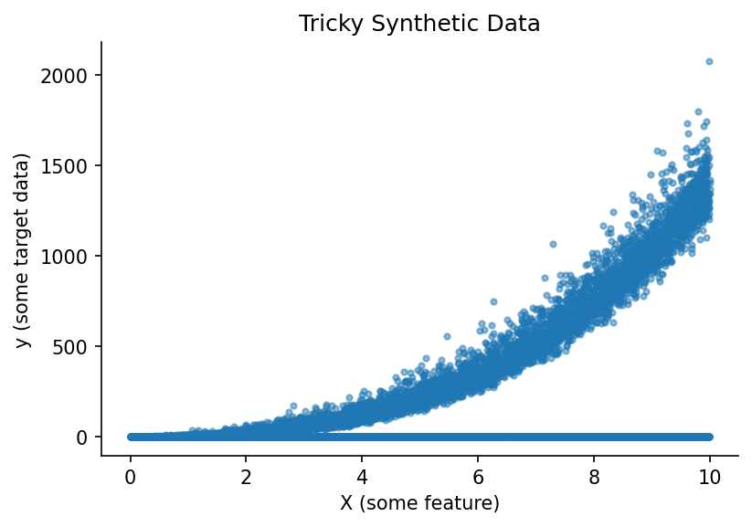

```python
f=plt.figure(dpi=150)
plt.title("Tricky Synthetic Data")
plt.scatter(X, y, alpha=0.5, marker=".")
plt.ylabel("y (some target data)")
plt.xlabel("X (some feature)")
sns.despine()
plt.show()
```

The plot above shows there is clearly a relationship between X and y. Some obvious characteristics of the target and feature space is the target data stuck at 0 (invariant of X) and the exponential looking bit. It also looks like the spread in the exponential looking part increases with increasing X.

An example of real-life data that may look like this is the relationship between predicted (forecast) precipitation (rain) and observed rain. $i.e.$, there are many possible outcomes (y) for a given set of information (features) used to predict rainfall (X). In general, there is always a chance that no rain occurs even if a large amount is possible and a gamma function can be useful to represent this type of characteristic [if you are curious about this particular problem check out these papers](https://journals.ametsoc.org/view/journals/wefo/30/2/waf-d-14-00054_1.xml).

Lets train a couple of simple neural networks and see which one seems more useful trying to predict y using X.

```python
def build_simple_network(
    input_shape=1,
    n_members=10,
    neurons=100,
    output_activation='linear',
    loss="mae",
    model_name = "model_McModelFace",
    lr=0.001,
    compile_model=True
):
    """
    Simple neural network that outputs "ensemble" members that are
    meant to represent an equally likely estimate of the target.
    Can learn any distribution when trained with CRPS loss. Fully
    connected layers with leaky_relu activation.

    Parameters
    ----------
    input_shape : int, default=1
        The number of features for training
    n_members : int, default=10
        The number of ensemble estimates to use to estimate the target.
        should be 1 unless loss is crps_sample_score()
    neurons : int
        The number of nodes in each hidden layer
    output_activation : str or tf.nn.activation_function
        The activation function used on the output layer.
    loss : str or function, default="mae"
        The loss function for the network
    model_name : str, default="model_McModelFace"
        The name of the returned model
    lr : float, default=0.001
        model learning rate
    compile_model : bool, default=True
        Whether to compile model before returning

    Return
    ------
    tensorflow.keras.Model
    """

    inputs = Input(shape=(input_shape,))

    # Create the hidden layers
    x = Dense(neurons, activation=tf.nn.leaky_relu, name="L1")(inputs)
    x = K.layers.Dropout(0.05)(x)
    x = Dense(neurons, activation=tf.nn.leaky_relu, name="L2")(x)
    x = K.layers.Dropout(0.05)(x)
    x = Dense(neurons, activation=tf.nn.leaky_relu, name="L3")(x)

    # Create the distribution parameters---
    outputs = Dense(n_members, activation=output_activation, name="ensemble_members")(x)

    model = K.Model(inputs=inputs, outputs=outputs, name=model_name)

    if compile_model :

        opt = tf.keras.optimizers.Adam(learning_rate=lr)
        model.compile(loss=loss, optimizer=opt)

    return model
```

```python
# Split up the data for training and "testing"
# TODO: We are going to play fast and loose with test and validation data in this notebook,
# TODO: for ease of demonstration purposes
X_train, X_test, y_train, y_test = train_test_split(X, y, test_size=0.3, random_state=10, shuffle=True)
```

### Train the simple models

Train a model with mean absolute error as a loss function and crps_sample_score as a loss function. We will go into the details of the CRPS loss function in a bit.

```python
tf.keras.backend.clear_session()

# The conditions of early stopping. For callbacks arg in .fit method
monitor = EarlyStopping(
    monitor='val_loss',
    min_delta=0.0,
    patience=4,
    verbose=1,
    mode='auto',
    restore_best_weights=True
)

# Create a model with a mean absolute error loss function
mae_model = build_simple_network(
    input_shape=1,
    n_members=1,
    neurons=30,
    output_activation='linear',
    loss="mae",
    model_name = "mae_model",
)

# Train it!
mae_model.fit(
    x=X_train,
    y=y_train,
    epochs=100,
    validation_data=(X_test, y_test),
    callbacks=[monitor],
    batch_size=128,
    verbose=1
)


# Build/Train CRPS-net model. We will dig into the details of
# crps_sample_score in just a minute.
# NOTE: n_members is the number of predictions made by the model
crps_net = build_simple_network(
    input_shape=1,
    n_members=51,
    neurons=30,
    output_activation='linear',
    loss=crps_sample_score,
    model_name = "crps-net"
)

crps_net.fit(
    x=X_train,
    y=y_train,
    epochs=100,
    validation_data=(X_test, y_test),
    callbacks=[monitor],
    batch_size=128,
    verbose=1
)
```

### Side by side results: CRPS-Net vs. MAE model

```python
# Make predictions across the range of the feature X
x_span = np.expand_dims(np.linspace(np.min(X), np.max(X), 1000), 1)

# Predict with both models
mae_pred = mae_model.predict(x_span)
crps_net_pred = crps_net.predict(x_span)
```

```python
# NOTE: the predictions of CRPS-net are a bit funky
# NOTE: compared to most regression-like loss functions.
# This post is going to spend a lot of time going over how to use this output
# dim = [example, pseudo ensemble member]
crps_net_pred.shape
```

```
(1000, 51)
```

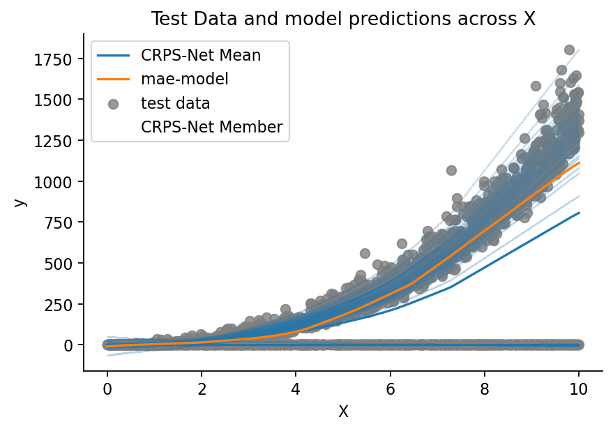

```python
fig = plt.figure(dpi=160)

plt.scatter(X_test, y_test, c="gray", alpha=0.8, label="test data")

# Since there is more than one predicted outcome per set of features
# plotting crps-net predictions requires additional care
for member in range(crps_net_pred.shape[1]) :
    plt.scatter(
        x_span, crps_net_pred[:, member],
        c="C0", alpha=0.2, s=0.2, marker="."
    )
# Add this just to get the legend for the members
plt.scatter(
    x_span, crps_net_pred[:, member],
    c="C0", alpha=0.0, s=0.2, marker=".", label="CRPS-Net Member"
)

# Show the mean of the CRPS-net prediction also by taking the mean across members
plt.plot(
    x_span, crps_net_pred.mean(axis=1), c="C0", alpha=1, label="CRPS-Net Mean"
)
plt.plot(x_span, mae_pred, label="mae-model", c="C1")
plt.xlabel("X")
plt.ylabel("y")
plt.title("Test Data and model predictions across X")
sns.despine()
plt.legend()

plt.show()
```

Before we move onto metrics for assessing the possible value of these predictions lets first point out some of the stuff happening in the above plot.

- The MAE-model predictions (orange) tracks the gamma component of the data nicely and clearly demonstrates how a simple neural network can easily learn a non-linear relationship.
- The MAE-model does not give you any information about the persistent target data (half in this case) stubbornly stuck at zero. It never predicts this value, even though it is half of the outcomes. Not ideal. It also does not easily give you any information about how the spread in y increases (a lot) with increasing X.
- CRPS-net captures both branches of the target data. It even seems to capture how the spread in possible outcomes of y increases with increasing X.
- The density of CRPS-net model predictions seems to match the density of outcomes in the target data. The model seems to minimize the distance between the examples in the target data and the predicted ensemble members.
- Neither make predictions where there are no target data, nice.
- I have plotted the mean of the CPRS-net model predictions as reference and to show those that may be resistance to using multiple outputs as predictions that this can be an option, though you lose much of the value of CRPS-net, which I hope you better outline below.

## Introduction to the Continuous Ranked Probability Score (CRPS)

"CRPS" has been thrown around a lot so far without giving a formal definition yet. Sorry, I just wanted to make sure you were hooked before dropping some equations. The CRPS was invented to enable direct comparisons of deterministic (single value) and probabilistic predictions. It is the analog of mean absolute error for multiple equally likely predictions. The formal definition is,

$$CRPS=\int_{-\infty}^{\infty} (F(y) - \textbf{1}|y \geq x|)^2 dy$$

Where F is the predicted cumulative density function (CDF), y is a random variable, and x is the observed value, and $\textbf{1}$ is the [heaviside function](https://en.wikipedia.org/wiki/Heaviside_step_function), which is equal to one where F(y) is greater than x and 0 elsewhere. This equation is easier to think about when represented graphically. Graphically, the CRPS is the area between the prediction CDF and the observed outcome CDF. This is sketched graphically below, first for a deterministic prediction, then a probabilistic prediction, and finally, a comparison of the two.

[figure not shown]

The bottom of the above figure compares the CRPS (the same units as the predicted variable) for the point prediction and the probabilistic prediction shown as a CDF. For this very professional but still leaves something to be desired sketch, it is not clear which area is smaller, but you get the idea! This shows how the CRPS is useful for making direct comparisons of point predictions and probabilistic predictions. For a very thorough overview of CRPS, take a look at [this paper](https://sites.stat.washington.edu/raftery/Research/PDF/Gneiting2007jasa.pdf).

### Note on Mixture Density Networks

Mixture density networks can make these types of probabilistic predictions (e.g. blue CDF above) by predicting the moments of a predicted distribution (e.g. normal distribution $\mu$ and $\sigma$). There is [a great blog post](https://github.com/oborchers/Medium_Repo) that walks you through doing this. However, one of the weaknesses of mixture density networks is that you need to define F a priori in order to predict the moments of F. This can be a hassle if you do not know the ideal distribution, if a complex mix of distributions is needed, or if you want to train a single model for many applications. To make the predictions nonparametric we want to get rid of having to define $F$ above. There are papers that measure the CRPS of predictions, but to date, only for distributions defined a priori ([e.g.](https://journals.ametsoc.org/view/journals/mwre/146/11/mwr-d-18-0187.1.xml)). There is an alternative form of the CRPS that lets us accomplish this!

### CRPS-Net: Detailed description

OK lets go over the mathematical backbone of CRPS-Net. The desired probabilistic neural network output $\hat{Y}$ is a matrix with dimensions number of examples (N) by number of predictions per example (G) and can be defined with the following mathematical notation:

$$\hat{Y}=f(\bf{X}; \Theta)$$

Where f(ᐧ) is a neural network, $\bf{X}$ is a N x P matrix of P (integer) input features, $\Theta$ is a set of parameters defining the neural network architecture (e.g. {number of hidden layers, nodes in layers, activation functions} ∈ $\Theta$), and where G ∈ ϴ is an integer specifying the network output size 1 X G for a given prediction $\hat{Y}_i$.

For a given $\hat{Y}_i$ of size 1 X G, each of the G predicted values can be treated as an equally likely prediction of the target variable y. In other words, $\hat{Y}_i$ can be treated as a random sample of the target variable (y) distribution for the given set of input features $\bf{X_i}$. This interpretation of $\hat{Y}$ is only valid when G is sufficiently large to portray the distribution of y for a given $\bf{X}$ and f(ᐧ) is trained using the sampled-based version of the Continuous Ranked Probability Score (CRPS) as its loss function.

$$CRPS(\hat{Y}, y) = E_F|\hat{Y} - y| - 1/2 \times E_F|\hat{Y} - \hat{Y}^{\prime}|$$

Where ${\hat{Y}^\prime}$ is an independent transposed copy of $\hat{Y}$ and E represents the expected value function. The first term represents the mean absolute error between the f(ᐧ) predictions $\hat{Y}$ and the target variable y. The second term is half the mean absolute value of the pairwise difference of all predicted values for a given example (spread in predictions for a given example). When f(ᐧ) is configured such that G=1, the second term in the CRPS is equal to zero and the neural network behaves identically to a neural network trained with the mean absolute error loss function. These are the key network requirements for CRPS-Net. The rest of the network parameters $\Theta$ and choices for training and optimising can vary widely and retain the same properties for $\hat{Y}$.

This neural network framework can completely replace the need for learning the moments of a hypothesized target distribution, as the G predictions for a given $\hat{Y}_i$ can be treated as a random sample of the predictand distribution. For example, say $\bf{X}$ and y are related by a physical process, but due to limited resolution of predictor observations $\bf{X}$, $y_i$ is observed to take on any value from a normal distribution with parameters $\mu$ and $\sigma$ for a given predictor $\bf{X_i}$. The mean and standard deviation of $\hat{Y}_i$ from $f(\bf{X_i, \Theta})$ can be viewed as sample estimates of the population parameters $\mu$ and $\sigma$. The larger G, the more accurate these sample estimates of the population parameters become. This interpretation can generalize to any parametric or observed distribution and has been tested on many, including gamma, point-mass, normal, tweedie, truncated normal, exponential, mixtures of these, and other synthetic mixtures.

### Simple metrics

The next section will score the above model predictions and show some of the utility/value of the CRPS-net model predictions.

```python
from sklearn.metrics import mean_absolute_error
from properscoring import crps_ensemble
```

```python
target = np.array(2, dtype=np.float32).reshape(-1, 1)
point_prediction = np.array(3, dtype=np.float32).reshape(-1, 1)

print("Mean abolute Error: ", mean_absolute_error(target, point_prediction))
print("CRPS-sample score loss function: ", crps_sample_score(target, point_prediction))
print("CRPS ensemble from proper scoring package:", crps_ensemble(target, point_prediction))
```

```
Mean abolute Error:  1.0
CRPS-sample score loss function:  tf.Tensor(1.0, shape=(), dtype=float32)
CRPS ensemble from proper scoring package: [[1.]]
```

Ignoring the fact that crps_sample_score returns a tensor (for now, this makes it a more efficient loss function for TF), we can see that they clearly have the same result for the same inputs! The mathematical proof for these equivalence and the formulation of the crps sample score can be found in [Gneiting & Raftery, 2005](https://stat.uw.edu/sites/default/files/files/reports/2004/tr463R.pdf), but hopefully this is enough for you to believe me when I saw that the CRPS is just the mean absolute error, and can be directly compared to MAE for point prediction (deterministic) predictions.

```python
mae_model_crps = crps_ensemble(y_test, mae_model.predict(X_test))
crps_net_crps = crps_ensemble(y_test.flatten(), crps_net.predict(X_test))
```

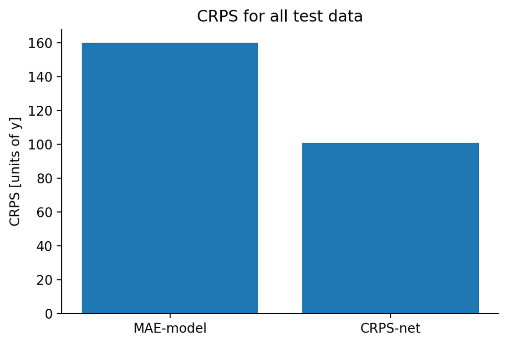

```python
plt.figure(dpi=200)
ax = plt.subplot(111)
p1 = ax.bar(
    x=(1, 2),
    height=(mae_model_crps.mean(), crps_net_crps.mean()),
)
ax.set_xticks((1,2))
ax.set_xticklabels(('MAE-model', 'CRPS-net'))
plt.title("CRPS for all test data")
sns.despine()
plt.ylabel("CRPS [units of y]")
plt.show()
```

For this population the CRPS-net has a much lower CRPS. Note how I have not added error bars to these bars, something I am generally ashamed to omit. However, it is actually kind of non-trivial to add error bars to the plot above since the standard deviation is a function of X. A meaningful comparison between the two models mean CRPS should really be a function of X.

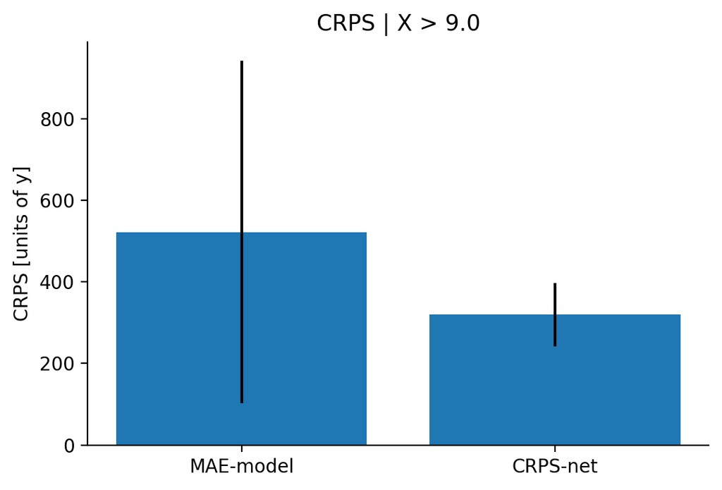

```python
min_x_value = 9.

mae_subset =  mae_model_crps[X_test.flatten() > min_x_value]
crps_subset = crps_net_crps[X_test.flatten() > min_x_value]

plt.figure(dpi=200)
ax = plt.subplot(111)
p1 = ax.bar(
    x=(1,2),
    height=(mae_subset.mean(), crps_subset.mean()),
    yerr=(mae_subset.std(), crps_subset.std())
)
ax.set_xticks((1,2))
ax.set_xticklabels(('MAE-model', 'CRPS-net'))
sns.despine()
plt.title(f"CRPS | X > {min_x_value}")
plt.ylabel("CRPS [units of y]")
plt.show()
```

Given how wide these standard deviation error bars are, lets take a quick look at a t-test to see if these two values are statistically different from one another.

```python
mae_subset.ravel().shape
```

```
(301,)
```

```python
from scipy import stats
stats.ttest_rel(mae_subset.ravel(), crps_subset.ravel())
```

```
Ttest_relResult(statistic=9.845463371410835, pvalue=5.3134916356290074e-20)
```

This starts to help us see which model is more valuable for different parts of the prediction feature space.

Intuitively we know that the difference in the value of these predictions is even bigger than what is shown by the above plot.

```python
from ensemble.ensemble_tools import probability_from_members, prob_between_values
```

```python
# Very simple example, what is the probability of exceeding some threshold
# given some predicted set of possible outcomes?
members = np.array([[-1.0, -1.0, 0.0, 0.0, 0.1, 0.2, 0.5, 0.5, 1.0, 1.0]])
thresh = 0.
probability_from_members(thresh, members, operator_str="greater")
```

```
array([[0.63636364]])
```

```python
y_test_pred_crps_net = crps_net.predict(X_test)
y_test_pred_mae_net = mae_model.predict(X_test)
```

## Probability of events from ensemble predictions

In this section I will outline another great benefit of CRPS-Net: By predicting the entire distribution you do not need to turn your target data into categories (classes) to predict the probability of events you might care about. For example, you might be interested in predicting the precipitation total for some field tomorrow, but you may also be interested in knowing, given your prediction system, what is the probability of zero rain occuring?

Here is where its worth noting that the CRPS is the mathematical equivalent of the integral of [brier scores](https://en.wikipedia.org/wiki/Brier_score) over all real thresholds. The Brier Score measures the accuracy of a probabilistic prediction event.

### Compare this to a MAE/MSE trained models and a single classification model

- **Greater than**
- **less than**
- **equal to**
  - **Brier scores for all**

This is where we will use ensemble and properscoring

Lets say that we want to know the Prob(y > 750 | X=8). Rather than training a classification model and changing our target y data to be either 0 or 1, based on whether it is higher than 750, we can use the output distributions of CRPS-Net and MAE-Net to estimate this probability. First, lets take a look at a look at the values y observed for values of X very near 8.

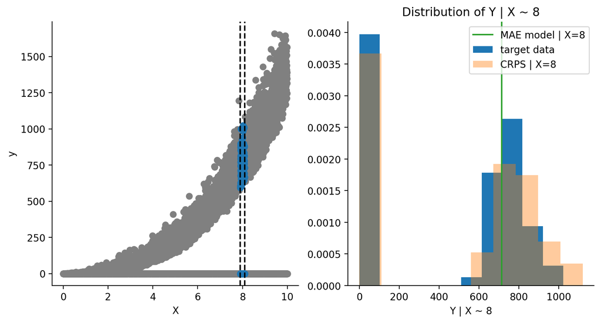

```python
threshold = 8
dx = 0.1

x_mask = (X >= threshold - dx) & (X <= threshold + dx)
y_subset = y[x_mask]

plt.figure(figsize=(10, 5), dpi=200)

plt.subplot(121)
plt.scatter(X, y, c="gray", label="target data")
plt.axvline(x=threshold - dx, c="k", linestyle="--")
plt.axvline(x=threshold + dx, c="k", linestyle="--")
plt.scatter(X[x_mask], y[x_mask], label="target data")
plt.xlabel("X")
plt.ylabel("y")

plt.subplot(122)
# Show the target data
plt.title("Distribution of Y | X ~ 8")
plt.hist(y_subset, density=True, label="target data", color="C0")


# Show the predictions for X=8 for both models
plt.hist(crps_net.predict([8]).ravel(), density=True,
         color="C1", label="CRPS | X=8", alpha=0.4)

plt.axvline(x=mae_model.predict([8]).ravel(),
            c="C2",
            label="MAE model | X=8")

plt.xlabel("Y | X ~ 8")
plt.legend()

sns.despine()
plt.show()
```

The above figure goes a long way towards showing that the CRPS-Net prediction gives a much more fully and transparent idea of what outcomes of y are possible for the given state of the predicted features (X). Though the deterministic MAE model prediction shown by the green line does on average minimize distance to possible outcomes, it gives no information about the nature of possible outcomes. For example, you would maybe never know that half of the outcomes will be zero, regardless of X. But let's move on, we want to know what is the probability that y will be greater than 750 or prob(y > 750 | X=8)?

```python
# Estimate the probability of values greater
crps_net_prob = probability_from_members(thresh=750, members=crps_net.predict([8]), operator_str="greater")
crps_net_prob
```

```
array([[0.39721341]])
```

```python
# Estimate the probability of values less
crps_net_prob = probability_from_members(thresh=750, members=crps_net.predict([8]), operator_str="less")
crps_net_prob
```

```
array([[0.60278659]])
```

```python
crps_net_prob = prob_between_values(members=crps_net.predict([8]), lower=-10000, upper=10000)
crps_net_prob
```

```
array([[1.]])
```

```python
# Deterministic predictions can only give you probabilities of
# 0 or 1. The event is either predicted to occur or not. No additional
# information is provided.
mae_event_prob = int(mae_model.predict([8]) > 750)
mae_event_prob
```

```
0
```

Given the various observed values of y given X (nearly) equal to 8 shown in the plot above, clearly the probability of y exceeding 750 is much higher than 0. The Brier score is one way of measuring the accuracy of a probabilistic prediction. Let's show what they are for these two predictions.

$$bs=\frac{1}{N}\sum_{t=0}^{N}(f_t - O_t)^2$$

Where N is the total number of examples, $f_t$ is the forecast probability and $O_t$ is whether the event occured (1) or not (0).

```python
# import some handy scoring tools from another TCC repo!
from properscoring import threshold_brier_score
```

```python
# recall, each prediction has 51 pseudeo ensemble members!
y_test_pred_crps_net.shape
```

```
(3000, 51)
```

```python
event_observed = (y_test > 750).astype(int)
# TODO: How does this calculate the probability of events? Voting? Thats not ideal...
crps_bs = threshold_brier_score(event_observed.ravel(), y_test_pred_crps_net, threshold=750)
mae_bs = threshold_brier_score(event_observed.ravel(), y_test_pred_mae_net, threshold=750)
```

```python
print("CRPS-Net Brier Score", crps_bs.mean())
print("MAE model Brier Score", mae_bs.mean())
```

```
CRPS-Net Brier Score 0.06759823144944253
MAE model Brier Score 0.18333333333333332
```

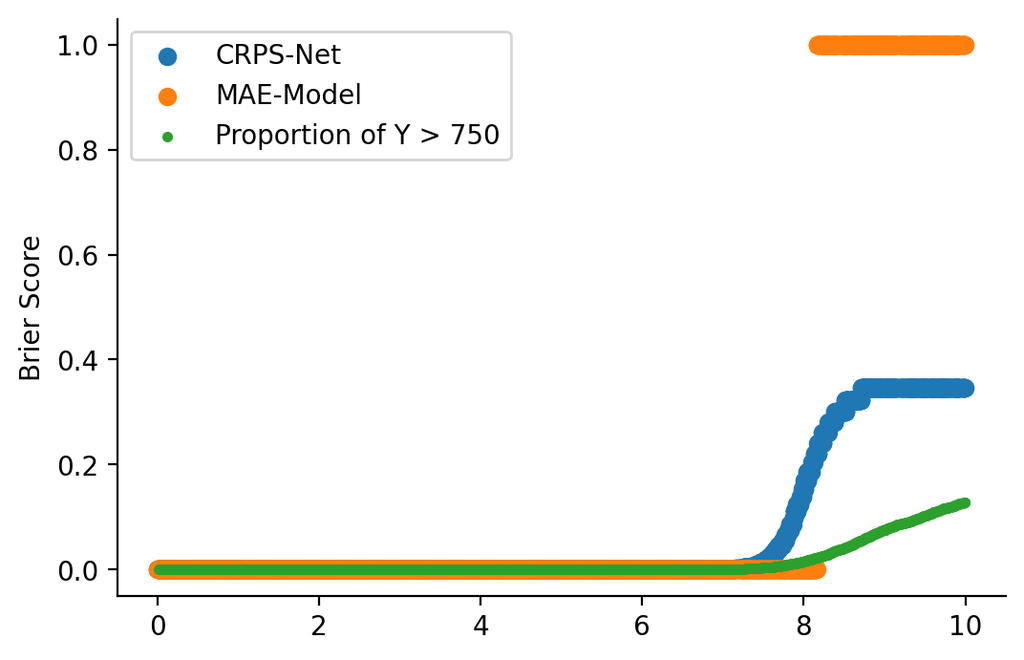

```python
proportion_above = []
for x in x_span :

    mask = X < x
    y_subset = y[mask]
    proportion_above.append(np.sum(y_subset > 750) / len(y_subset))

plt.figure(dpi=200)
plt.scatter(X_test, crps_bs, label="CRPS-Net")
plt.scatter(X_test, mae_bs, label="MAE-Model")
plt.scatter(x_span, np.array(proportion_above), label="Proportion of Y > 750", marker=".")
plt.ylabel("Brier Score")
plt.legend()
sns.despine()
```

```python
print("Brier scores in a more relevent subset of the data (X > 7)")
print("CRPS-Net Brier Score", crps_bs[(X_test>7).ravel()].mean())
print("MAE model Brier Score", mae_bs[(X_test>7).ravel()].mean())
```

```
Brier scores in a more relevent subset of the data (X > 7)
CRPS-Net Brier Score 0.22734012271927145
MAE model Brier Score 0.6165919282511211
```

### CRPS-Net can have utility for predictions that extrapolate beyond the training data

You may be thinking, "cool results, I will probably tweet about this and give you a high five if we ever meet, but what happens when CRPS-Net has to make predictions for a test set that are not drawn from the same distribution as the training data"? Great question! In data science we like to think that we are going to make predictions on data drawn from the same distribution as what we trained our models on, but sometimes the universe is not this generous. You might think this is the exact time it would be idea to have a model capable of reliable estimates of uncertainty. Lets see how CRPS-Net does in an example of this situation.

You will also notice that we played fast and loose with our "test" data by using it for validation during training. Generally not a pro move, so lets handle that right now.

```python
test_mask = X > 8
train_mask = ~ test_mask

X_train_all, y_train_all, X_test, y_test = X[train_mask], y[train_mask], X[test_mask], y[test_mask]
X_train, X_validation, y_train, y_validation = train_test_split(X_train_all, y_train_all, test_size=0.33)
```

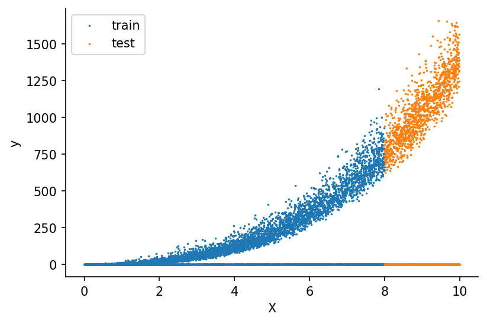

```python
f = plt.figure(dpi=150)

plt.scatter(X[train_mask], y[train_mask], label="train", s=0.5)
plt.scatter(X[test_mask], y[test_mask], label="test", s=0.5)
plt.ylabel("y")
plt.xlabel("X")
plt.legend()

sns.despine()
```

#### Train a new set of models on this harder problem

```python
tf.keras.backend.clear_session()

# Create a model with a mean absolute error loss function
mae_model = build_simple_network(
    input_shape=1,
    n_members=1,
    neurons=30,
    output_activation='linear',
    loss="mae",
    model_name = "mae_model",
)

# Train it!
mae_model.fit(
    x=X_train,
    y=y_train,
    epochs=100,
    validation_data=(X_validation, y_validation),
    callbacks=[monitor],
    batch_size=128,
    verbose=1
)


# Build/Train CRPS-net model. We will dig into the details of
# crps_sample_score in just a minute.
# NOTE: n_members is the number of predictions made by the model
crps_net = build_simple_network(
    input_shape=1,
    n_members=51,
    neurons=30,
    output_activation='linear',
    loss=crps_sample_score,
    model_name = "crps-net"
)

crps_net.fit(
    x=X_train,
    y=y_train,
    epochs=100,
    validation_data=(X_validation, y_validation),
    callbacks=[monitor],
    batch_size=128,
    verbose=1
)
```

```
Restoring model weights from the end of the best epoch.
Epoch 00071: early stopping
Restoring model weights from the end of the best epoch.
Epoch 00099: early stopping
```

```
<tensorflow.python.keras.callbacks.History at 0x7ff7e052eb00>
```

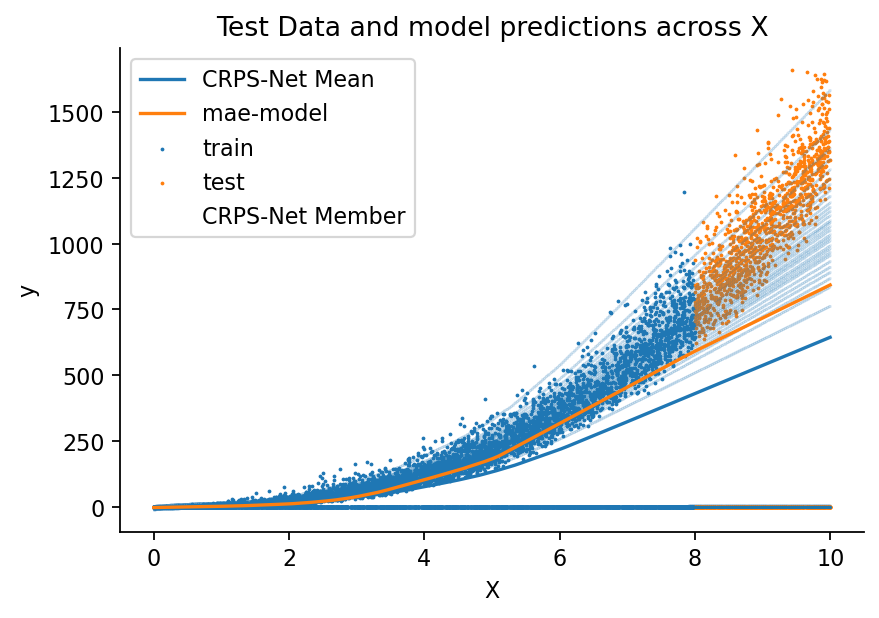

```python
# Make predictions across the range of the feature X
x_span = np.expand_dims(np.linspace(np.min(X), np.max(X), 1000), 1)

# Predict with both models
mae_pred = mae_model.predict(x_span)
crps_net_pred = crps_net.predict(x_span)


fig = plt.figure(dpi=160)

plt.scatter(X[train_mask], y[train_mask], label="train", s=0.5)
plt.scatter(X[test_mask], y[test_mask], label="test", s=0.5)

# Since there is more than one predicted outcome per set of features
# plotting crps-net predictions requires additional care
for member in range(crps_net_pred.shape[1]) :
    plt.scatter(
        x_span, crps_net_pred[:, member],
        c="C0", alpha=0.2, s=0.2, marker="."
    )
# Add this just to get the legend for the members
plt.scatter(
    x_span, crps_net_pred[:, member],
    c="C0", alpha=0.0, s=0.2, marker=".", label="CRPS-Net Member"
)

# Show the mean of the CRPS-net prediction also by taking the mean across members
plt.plot(
    x_span, crps_net_pred.mean(axis=1), c="C0", alpha=1, label="CRPS-Net Mean"
)
plt.plot(x_span, mae_pred, label="mae-model", c="C1")
plt.xlabel("X")
plt.ylabel("y")
plt.title("Test Data and model predictions across X")
sns.despine()
plt.legend()

plt.show()
```

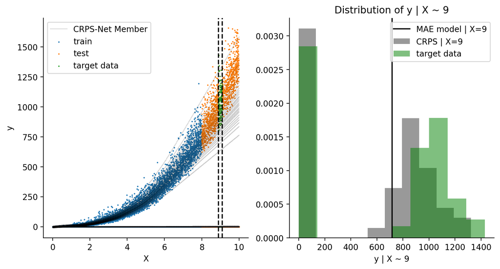

```python
threshold = 9
dx = 0.1

x_mask = (X >= threshold - dx) & (X <= threshold + dx)
y_subset = y[x_mask]

plt.figure(figsize=(10, 5), dpi=200)

plt.subplot(121)
plt.scatter(X[train_mask], y[train_mask], label="train", s=0.5)
plt.scatter(X[test_mask], y[test_mask], label="test", s=0.5)
plt.axvline(x=threshold - dx, c="k", linestyle="--")
plt.axvline(x=threshold + dx, c="k", linestyle="--")
plt.scatter(X[x_mask], y[x_mask], label="target data", s=0.5)

for member in range(crps_net_pred.shape[1]) :
    plt.scatter(
        x_span, crps_net_pred[:, member],
        c="k", alpha=0.1, s=0.2, marker="."
    )
# Add this just to get the legend for the members
plt.plot(
    x_span, crps_net_pred[:, member],
    c="k", alpha=0.1, label="CRPS-Net Member"
)

plt.xlabel("X")
plt.ylabel("y")
plt.legend()

plt.subplot(122)
# Show the target data
plt.title(f"Distribution of y | X ~ {threshold}")
# Show the predictions for X=8 for both models
plt.hist(crps_net.predict([threshold]).ravel(), density=True,
         color="k", label=f"CRPS | X={threshold}", alpha=0.4)
plt.axvline(x=mae_model.predict([threshold]).ravel(),
            c="k", label=f"MAE model | X={threshold}")
plt.hist(y_subset, density=True, label="target data", color="green", alpha=0.5)



plt.xlabel(f"y | X ~ {threshold}")
plt.legend()

sns.despine()
plt.show()
```

## Wrap up

Hopefully this notebook has demonstrated some of the value of probabilistic predictions and how CRPS-Net (using crps_sample_score() as your loss function and multiple outputs in the final layer of your neural network) can help you easily make these kinds of predictions! Don't forget, the number of neurons in your output layer (the so-called pseudo ensemble members) is a new hyperparameter! Make sure to tune this for your modeling problem.